# Chapter 11 Multidimensional Scaling (MDS)

## Introduction

**Multidimensional Scaling (MDS)** is a technique used to reduce the dimensionality of data while preserving the **pairwise distances** (or dissimilarities) between observations. It transforms complex, high-dimensional relationships into a **geometric map** that is easy to visualize—typically in 2D or 3D. MDS is commonly used in **psychology**, **sociology**, **marketing research**, and **bioinformatics** to uncover hidden patterns or perceptual similarities among objects.

The main objective of MDS is to find a **low-dimensional representation** of a high-dimensional dataset that preserves the **pairwise distances** as accurately as possible. This is achieved by **minimizing a stress function**, which measures the difference between the original and the low-dimensional pairwise distances.

Given a **dissimilarity matrix**
$$ D = (d_{ij})_{p \times p}, $$
the goal is to find
$$ x_1, x_2, \ldots, x_n \in \mathbb{R}^k $$
such that

$$ \underbrace{d_{ij}^2}_{\text{raw distance}} \approx \underbrace{\|x_i - x_j\|^2}_{\text{distance in new configuration}} $$

The resulting configuration—typically in a low-dimensional space like $\mathbb{R}^2$—should preserve the Euclidean distances as closely as possible to the original dissimilarities or similarities.

## Classical (Metric) MDS

When the original distances are **Euclidean**, *Classical MDS* provides an algebraic solution that reconstructs the configuration of points.

Starting from the squared dissimilarity matrix $\Delta^{(2)} = [d_{ij}^2]$, we compute the **centered inner-product matrix**:

$$ B = -\frac{1}{2} J \, \Delta^{(2)} J, $$

where  
$J = I - \frac{1}{n}\mathbf{1}\mathbf{1}^T$  
is the **centering matrix** used to remove the mean of the distances.

Then we perform **eigen decomposition**:

$$ B = Q \Lambda Q^T, $$

where $\Lambda$ contains the eigenvalues and $Q$ the eigenvectors.  
The coordinates in a $k$-dimensional space are given by:

$$ X = Q_k \Lambda_k^{1/2}. $$

Each row of $X$ represents one object in the new low-dimensional configuration.

**Key property:**  
Classical MDS preserves **global pairwise similarities** between all points.  
It differs from manifold learning algorithms (like t-SNE or Isomap), which focus more on **local neighborhood preservation**.  
However, MDS is limited in modeling **nonlinear relationships** since it is based on Euclidean geometry.

## Metric vs. Non-Metric MDS

| Type | Preserves | Uses | Typical Data |
| --- | --- | --- | --- |
| **Metric MDS** | Exact distances | Linear relationships | Euclidean or quantitative dissimilarities |
| **Non-Metric MDS** | Rank order of distances | Monotonic transformations | Ordinal or qualitative dissimilarities |

**Classical MDS**: When the original distances are Euclidean, classical multidimensional scaling is used to find a configuration such that the configured distances are approximately equal to the original Euclidean distances. It focuses on global similarities , which are different with many manifold learning algorithms, which emphasize preserving local neighborhood relationships. MDS has limitations in producing non-linear embeddings. The original distances in $ D $ do not have to be Euclidean. They can represent any pairwise dissimilarities, even for qualitative comparisons between various objects. The algorithm is adapted based on whether the original distances are Euclidean (classical MDS) or non-Euclidean, or when dealing with qualitative similarities (general metric or non-metric MDS).

**Non-metric MDS**

Non-metric MDS differs by focusing on the rank-order relationships rather than the exact distances between items. It aims to find a monotonic relationship between the dissimilarities (or distances) in the original data and the Euclidean distances in the lower-dimensional space. This means that non-metric MDS does not preserve the exact numerical distances, but instead captures the general ordering of dissimilarities. It is a technique used to reduce complex, multidimensional data into a a lower (two-dimensional) representation or ordination. In the plot, points that are closer together indicate greater similarity between the corresponding samples.

It focuses on **rank-order relationships** rather than exact distances and finds a **monotonic transformation** $f(\cdot)$ such that

$$ d_{ij} \approx f(\delta_{ij}), $$

and minimizes the **Kruskal’s stress function**:

$$ \text{Stress} = \sqrt{\frac{\sum_{i<j} (d_{ij} - f(\delta_{ij}))^2}{\sum_{i<j} d_{ij}^2}}. $$

### 🧮 Class Example: Classical Multidimensional Scaling (MDS)

In this example, we apply **Classical MDS** to the built-in R dataset `USArrests`, which contains statistics on violent crime rates for the 50 U.S. states. The dataset includes four quantitative variables : **Murder**, **Assault**, **UrbanPop**, and **Rape** , each representing a different aspect of public safety and urbanization.

The goal is to **visualize the relationships among states** based on their overall crime patterns. Rather than comparing variables directly, we compute the **pairwise Euclidean distances** between states using all four variables.  
These distances measure how *similar* or *dissimilar* each state’s crime profile is compared to another’s.

Using **classical MDS** (`cmdscale()` in R), we project the 4-dimensional distance matrix onto a **2-dimensional map**, where each point corresponds to a state. The closer two states appear on the plot, the more similar their crime statistics are.

```r
library(ggplot2)
```

```r
str(USArrests)

head(USArrests)
```

```
'data.frame':	50 obs. of  4 variables:
 $ Murder  : num  13.2 10 8.1 8.8 9 7.9 3.3 5.9 15.4 17.4 ...
 $ Assault : int  236 263 294 190 276 204 110 238 335 211 ...
 $ UrbanPop: int  58 48 80 50 91 78 77 72 80 60 ...
 $ Rape    : num  21.2 44.5 31 19.5 40.6 38.7 11.1 15.8 31.9 25.8 ...
```

A data.frame: 6 × 4

|  | Murder <dbl> | Assault <int> | UrbanPop <int> | Rape <dbl> |
| --- | --- | --- | --- | --- |
| Alabama | 13.2 | 236 | 58 | 21.2 |
| Alaska | 10.0 | 263 | 48 | 44.5 |
| Arizona | 8.1 | 294 | 80 | 31.0 |
| Arkansas | 8.8 | 190 | 50 | 19.5 |
| California | 9.0 | 276 | 91 | 40.6 |
| Colorado | 7.9 | 204 | 78 | 38.7 |

```r
# Compute pairwise distances among states using USArrests data
dist.mat = dist(USArrests)

#dist.mat0 =as.matrix(dist.mat)
#dist.mat0[1:5, 1:5]
```

[output not shown]

```r
# Perform classical MDS (2D representation)
mds.fit = cmdscale(dist.mat, k = 2, eig = TRUE)

#summary(mds.fit)
```

[output not shown]

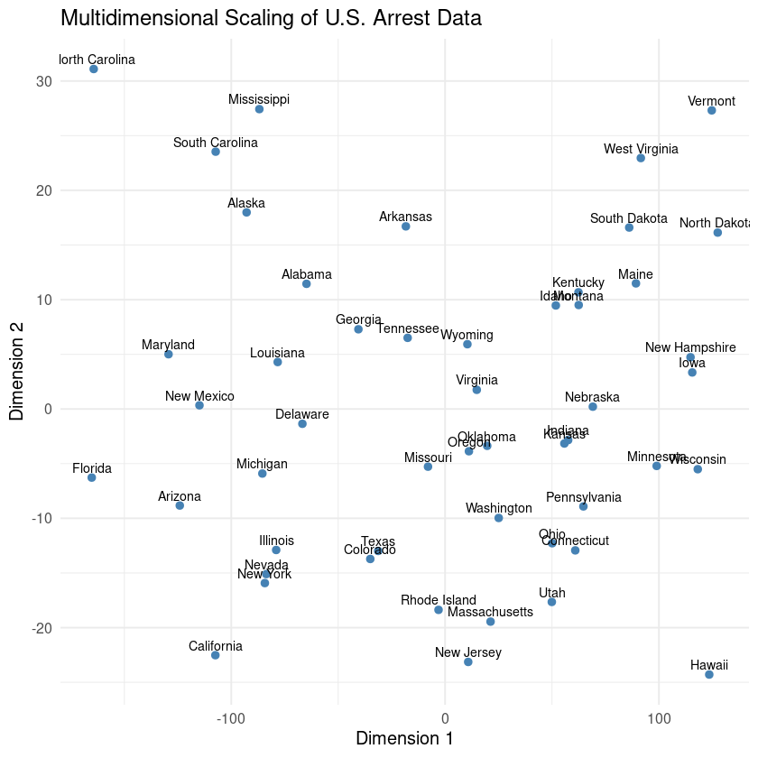

```r
#Distance visulization on 2d

# Prepare data for plotting
mds.dat = data.frame(
  Dim1 = mds.fit$points[, 1],
  Dim2 = mds.fit$points[, 2],
  State = rownames(USArrests)
)


# scatter plot in ggplot2
ggplot(mds.dat, aes(x = Dim1, y = Dim2, label = State)) +
  geom_point(color = "steelblue", size = 2) +
  geom_text(size = 3, vjust = -0.5) +
  theme_minimal(base_size = 12) +
  labs(
    title = "Multidimensional Scaling of U.S. Arrest Data",
    x = "Dimension 1",
    y = "Dimension 2"
  )
```

After running the code, the resulting MDS plot shows distinct regional patterns:

- States such as **Florida**, **California**, and **Nevada** often appear close together — reflecting **higher crime rates** and large urban populations.
- States such as **North Dakota**, **Maine**, and **Vermont** cluster together, indicating **lower crime levels**.
- The **spatial arrangement** of points provides a clear and interpretable visualization of how crime patterns vary across the U.S.

# 🌐 Non-Metric Multidimensional Scaling (NMDS)

**Non-Metric Multidimensional Scaling (NMDS)** is an extension of MDS that focuses on **preserving the rank order of dissimilarities** rather than the actual distances between observations. It is especially useful when the data represent **ordinal relationships**, qualitative similarities, or **nonlinear structures** where absolute distances are not meaningful. Instead of assuming linearity, NMDS applies a **monotonic transformation** to the dissimilarities, ensuring that the **relative ordering** of distances between objects is preserved in a low-dimensional space (typically 2D or 3D).

Unlike **classical (metric) MDS**, NMDS does not require the original distances to be Euclidean and is particularly robust for **ordinal, nonlinear, or ecological** data, where only relative similarity among observations matters. Furthermore, NMDS does not rely on an algebraic solution; it uses an **iterative numerical optimization process** to find a configuration that best maintains the rank ordering of pairwise dissimilarities in the reduced-dimensional representation.

Given a dissimilarity matrix
$$ \Delta = [\delta_{ij}], \quad i,j = 1, \dots, n, $$
NMDS seeks a configuration of points
$$ \mathbf{x}_1, \mathbf{x}_2, \dots, \mathbf{x}_n \in \mathbb{R}^p $$
such that their **Euclidean distances** $d_{ij}$ reflect the **rank order** of $\delta_{ij}$ as closely as possible.

A **monotonic transformation** $f(\cdot)$ is used to map the original dissimilarities to fitted distances:

$$ d_{ij} \approx f(\delta_{ij}). $$

The **stress function**, introduced by Kruskal (1964), measures the lack of fit between the dissimilarities and distances:

$$ \text{Stress} = \sqrt{ \frac{\sum_{i<j} (d_{ij} - f(\delta_{ij}))^2} {\sum_{i<j} d_{ij}^2} }. $$

A smaller stress value indicates a better fit:

- **Stress < 0.05:** Excellent
- **0.05–0.10:** Good
- **0.10–0.20:** Fair
- **> 0.20:** Poor representation

### 🧮 Class Example: Non-Metric Multidimensional Scaling (NMDS) with the *Iris* Dataset

In this example, we apply **Non-Metric Multidimensional Scaling (NMDS)** to the well-known `iris` dataset. The dataset contains **150 flower samples** representing three species : *setosa*, *versicolor*, and *virginica* . Each described by four quantitative variables: **Sepal.Length**, **Sepal.Width**, **Petal.Length**, and **Petal.Width**.

Our objective is to **visualize the relationships among flower samples** based on their overall morphological similarity. Rather than preserving the exact Euclidean distances, NMDS focuses on preserving the **rank order** of dissimilarities among samples, making it ideal for capturing nonlinear or ordinal relationships.

We first compute the **pairwise Euclidean dissimilarities** among all samples using their four continuous features. Next, we apply the **`isoMDS()`** function from the **MASS** package to find a two-dimensional configuration that best represents the rank-order structure of these dissimilarities.  
Finally, the resulting two-dimensional coordinates are visualized using **ggplot2** to show how the flower species cluster in the NMDS map.

This analysis allows us to explore the *relative similarity* between flower samples:

- Points that are **close together** in the NMDS plot represent flowers that are morphologically similar.
- Points that are **far apart** represent flowers with more distinct measurements.
- Well-separated clusters indicate **distinct species**, while overlapping regions reveal **species with similar features** (e.g., *versicolor* and *virginica*).

NMDS is particularly useful here because it captures the **ordinal structure** of relationships rather than exact metric distances, providing a flexible and intuitive visualization of how species differ in a reduced two-dimensional space.

```r
#Package for NMDS
library(MASS)

head(iris)
dat = iris[!duplicated(iris[, 1:4]), ]
dat0 = dat[,1:4]
```

A data.frame: 6 × 5

|  | Sepal.Length <dbl> | Sepal.Width <dbl> | Petal.Length <dbl> | Petal.Width <dbl> | Species <fct> |
| --- | --- | --- | --- | --- | --- |
| 1 | 5.1 | 3.5 | 1.4 | 0.2 | setosa |
| 2 | 4.9 | 3.0 | 1.4 | 0.2 | setosa |
| 3 | 4.7 | 3.2 | 1.3 | 0.2 | setosa |
| 4 | 4.6 | 3.1 | 1.5 | 0.2 | setosa |
| 5 | 5.0 | 3.6 | 1.4 | 0.2 | setosa |
| 6 | 5.4 | 3.9 | 1.7 | 0.4 | setosa |

```r
#Find the distance matrix
# Compute dissimilarities (Euclidean distances)
d.iris = dist(dat0)
```

```r
# Perform Non-Metric MDS (2D configuration)
nmds.iris = isoMDS(d.iris, k = 2)
```

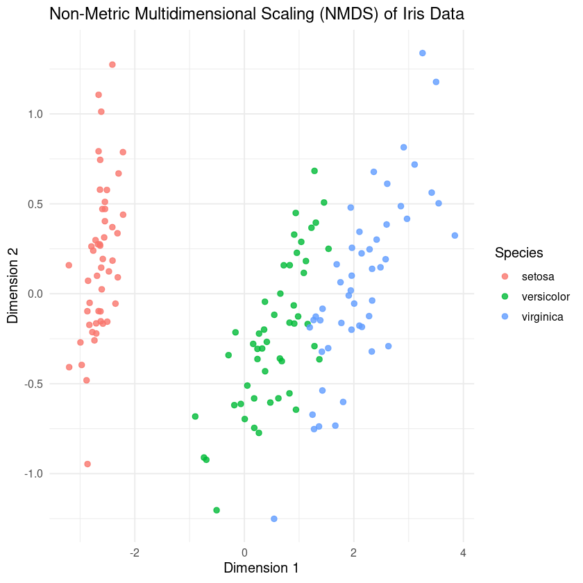

```r
# Prepare data for visualization
nmds.dat = data.frame(
  Dim1 = nmds.iris$points[, 1],
  Dim2 = nmds.iris$points[, 2],
  Species = dat$Species
)

#a clear two-dimensional visualization of the rank-order dissimilarities among the 150 iris samples based on their four morphological features (sepal length, sepal width, petal length, and petal width).
# Plot NMDS results
ggplot(nmds.dat, aes(x = Dim1, y = Dim2, color = Species)) +
  geom_point(size = 2, alpha = 0.8) +
  theme_minimal(base_size = 12) +
  labs(
    title = "Non-Metric Multidimensional Scaling (NMDS) of Iris Data",
    x = "Dimension 1",
    y = "Dimension 2",
    color = "Species"
  )
```

```r
# View the stress value from the NMDS model
nmds.iris$stress
```

2.57997863055485

Dimension 1 and Dimension 2 are artificial axes created to best represent the rank-order dissimilarities among observations in a reduced, low-dimensional space (usually 2D). Unlike methods such as PCA or LDA, these dimensions do not correspond to specific variables or linear combinations of the original features. Instead, they represent directions in the configuration that maximize the preservation of relative distances (i.e., the order of dissimilarities) among samples.